# Sprint 4 - Data Analysis

### Question: Which Genre Generates the Most Gross?

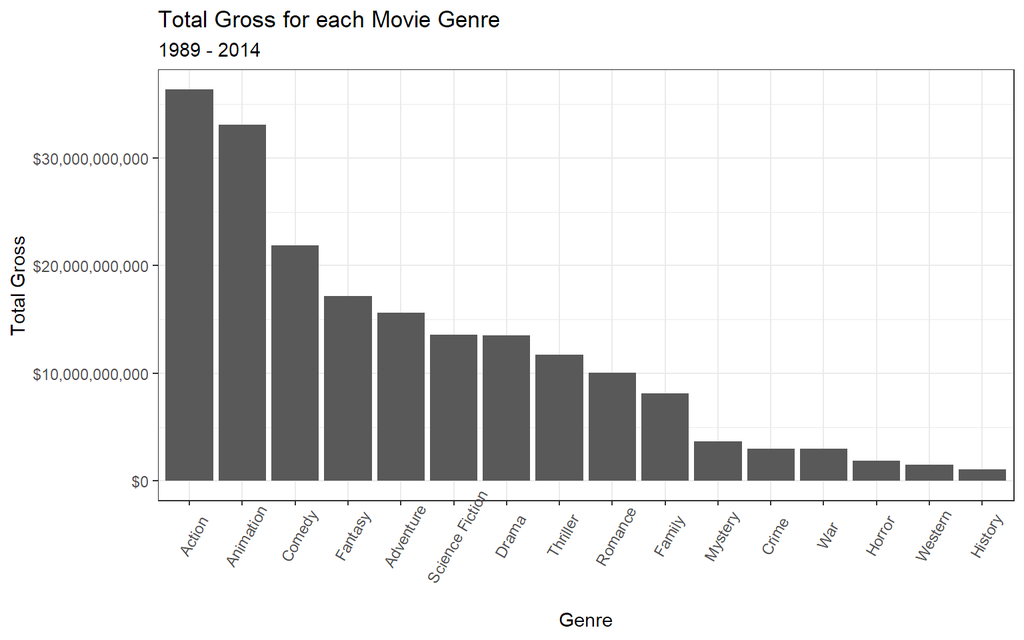

```r
movies %>%
  mutate(Profit = Gross - Budget) %>%
  group_by(Genre) %>%
  summarise("Average Gross" = mean(Gross),
            "Average Profit" = mean(Profit),
            Total_Gross = sum(Gross)) %>%
  ggplot(aes(x = reorder(Genre, -Total_Gross), y = Total_Gross)) +
  theme_bw()+
  geom_bar(stat = "identity")+
  scale_y_continuous(labels=scales::dollar_format()) +
  labs(x = "Genre", y = "Total Gross", title="Total Gross for each Movie Genre", subtitle = "1989 - 2014")+
  theme(axis.text.x = element_text(angle = 60, vjust = 0.75))
```

### Question: What is the Distribution of MPAA Ratings for each Genre?

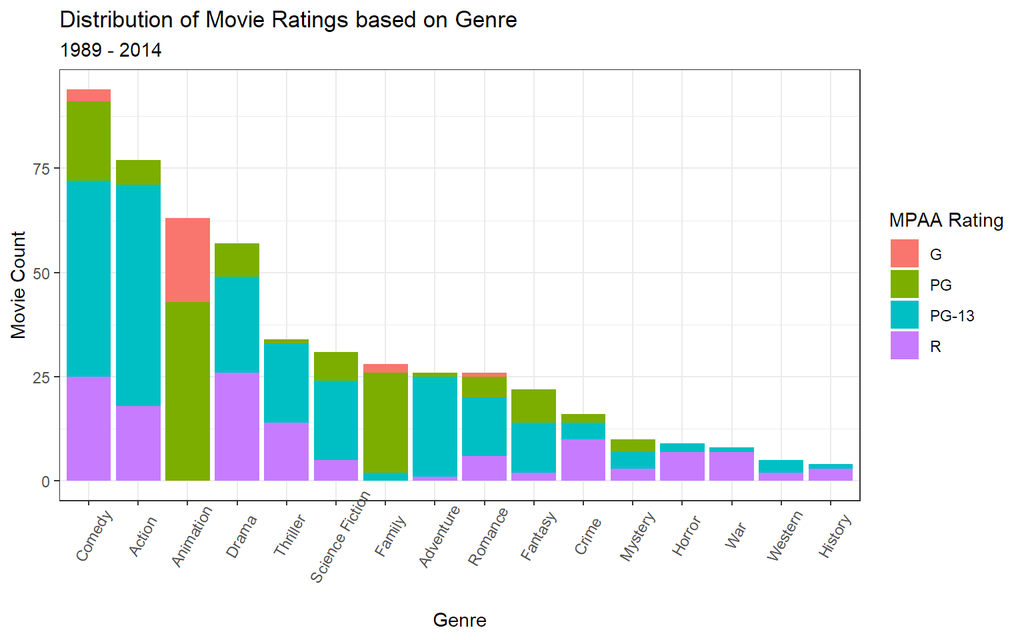

```r
movies %>%
  mutate(Profit = Gross - Budget) %>%
  group_by(Genre) %>%
  count(MPAA.Rating) %>%
  group_by(Genre) %>%
  summarise(total = sum(n),
            Genre = Genre,
            MPAA.Rating = MPAA.Rating,
            n = n) %>%
  ggplot(aes(x = reorder(Genre, -total), y = n, fill = MPAA.Rating)) +
  theme_bw()+
  geom_bar(stat = "identity") +
  labs(x = "Genre", y = "Movie Count", title = "Distribution of Movie Ratings based on Genre", subtitle = "1989 - 2014", fill = "MPAA Rating") +
  theme(axis.text.x = element_text(angle = 60, vjust = 0.75))
```

This data is designed to show off the distribution of movie ratings based off the genre of the movie as well as the distribution of movies. We can see that comedy is the genre with the highest number of movies, followed by action. Animation has the highest number of G and PG movies. Action has the highest number of PG-13 movies. Drama has the highest number of R rated movies.